# APC - EIOM 2023

Aurélien Nicosia

31 aout 2023

## Exemple 1 - USArrest

### Les données

On travaille sur le jeu de données USArrests, disponible automatiquement avec le logiciel R. Que contient-il?

```r
head(USArrests)
```

```
##            Murder Assault UrbanPop Rape
## Alabama      13.2     236       58 21.2
## Alaska       10.0     263       48 44.5
## Arizona       8.1     294       80 31.0
## Arkansas      8.8     190       50 19.5
## California    9.0     276       91 40.6
## Colorado      7.9     204       78 38.7
```

Vos notes ici :

Quelques statistiques descriptives :

```r
apply(USArrests , 2, mean)
```

```
##   Murder  Assault UrbanPop     Rape
##    7.788  170.760   65.540   21.232
```

```r
apply(USArrests, 2, var)
```

```
##     Murder    Assault   UrbanPop       Rape
##   18.97047 6945.16571  209.51878   87.72916
```

Que remarquez-vous?  
Vos notes ici :

Regardons maintenant la corrélation entre les variables.

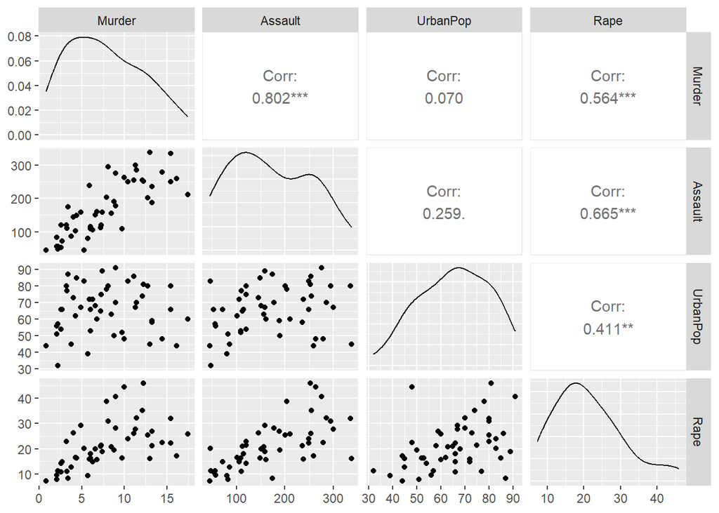

```r
library("ggplot2")
library("GGally")
ggpairs(USArrests)
```

Etes-vous capable d’identifier des états similaires par rapport à ces 4 variables? L’ACP pourra nous aider à le faire.

### Analyse en composantes principales (scale = TRUE)

Plusieurs fonctions issues de différents packages sont disponibles dans le logiciel R de calcul PCA :

- prcomp() et princomp() [package de statistiques R intégré],
- PCA() [library FactoMineR],
- dudi.pca() [library ade4]
- epPCA() [library Exposition]

Quelle que soit la fonction que vous décidez d’utiliser, vous pouvez facilement extraire et visualiser les résultats de l’ACP à l’aide des fonctions R fournies dans le package factoextra R.

```r
library("FactoMineR")
library("factoextra")
```

On commence par utiliser l’option scale = TRUE; on y reviendra. Que contient l’objet créé par la fonction?

```r
res.pca <- PCA(USArrests, scale = TRUE)
```

[figure not shown]

[figure not shown]

```r
# code ici
```

Vos notes ici :

**Visualisation**

Nous utiliserons le package factoextra R pour aider à l’interprétation de PCA. Quelle que soit la fonction que vous décidez d’utiliser [stats::prcomp(), FactoMiner::PCA(), ade4::dudi.pca(), ExPosition::epPCA()], vous pouvez facilement extraire et visualiser les résultats de la PCA en utilisant les fonctions R fournies dans le package factoextra R.

Ces fonctions incluent :

- get_eigenvalue(res.pca) : Extraire les valeurs propres/variances des composants principaux - fviz_eig(res.pca) : Visualisez les valeurs propres
- get_pca_ind(res.pca), get_pca_var(res.pca) : extrayez les résultats pour les individus et les variables, respectivement.
- fviz_pca_ind(res.pca), fviz_pca_var(res.pca) : Visualisez les résultats individus et variables, respectivement.
- fviz_pca_biplot(res.pca) : Créez un biplot d’individus et de variables.

On peut situer tous les états dans l’espace créé par les deux premières composantes principales. Que représentent les mots en noir? Les mots en bleu?

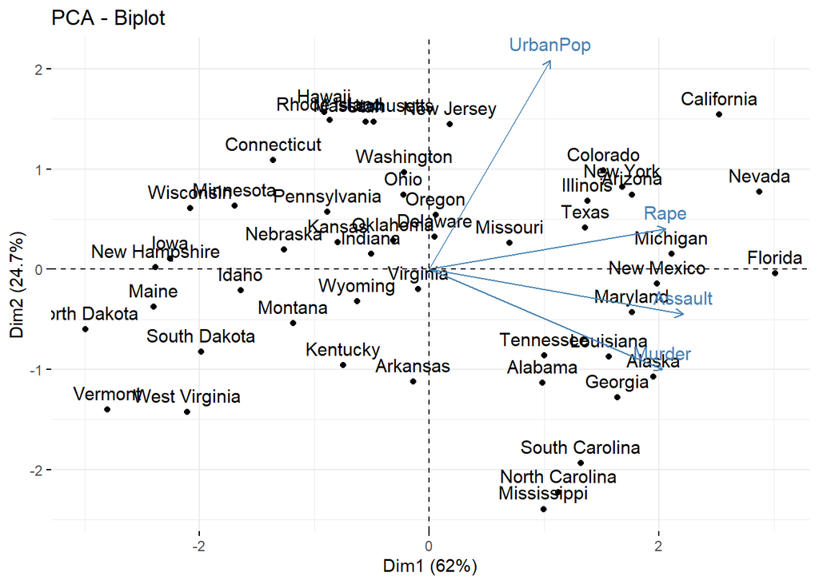

```r
fviz_pca_biplot(res.pca)
```

Vos notes ici :

Voyons si les premières composantes principales expliquent une grande partie de la variabilité.

```r
#extraction des valeurs propres
get_eigenvalue(res.pca)
```

```
##       eigenvalue variance.percent cumulative.variance.percent
## Dim.1  2.4802416        62.006039                    62.00604
## Dim.2  0.9897652        24.744129                    86.75017
## Dim.3  0.3565632         8.914080                    95.66425
## Dim.4  0.1734301         4.335752                   100.00000
```

Vos notes ici :

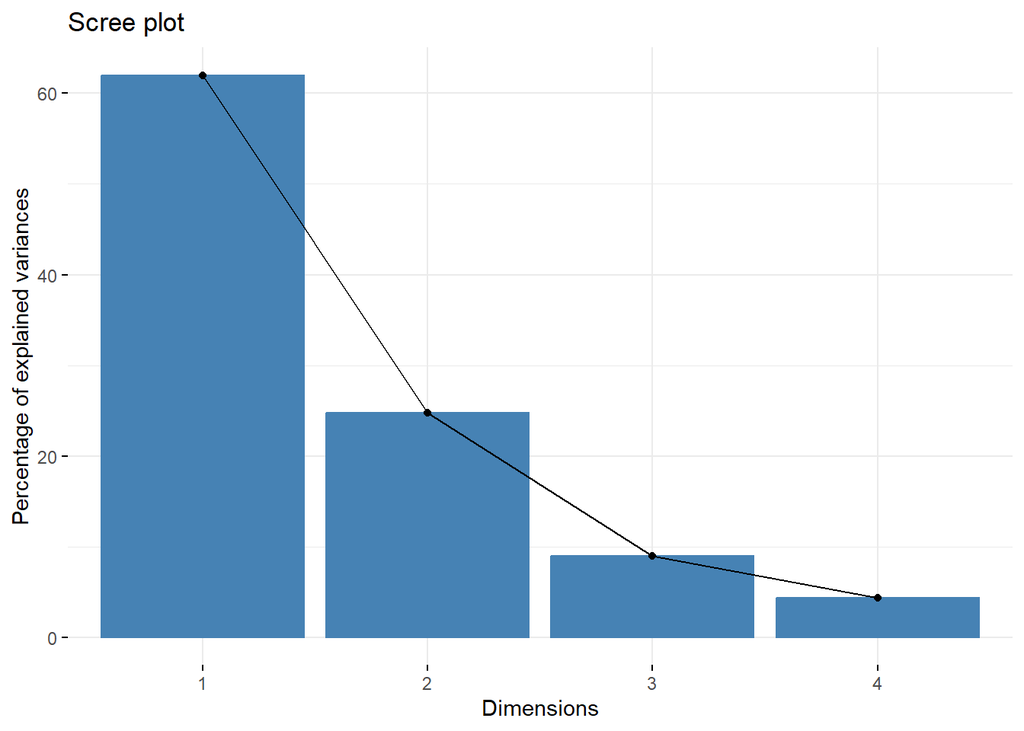

```r
# graphique
fviz_eig(res.pca)
```

Est-ce que ça semble une bonne idée de regarder uniquement les deux premières composantes principales?  
Vos notes ici :

## Analyse en composantes principales (scale = FALSE)

Qu’est-ce qui se passe dans ce cas? A vous de jouer!

```r
#Vos codes ici
```

Vos notes ici :

## Données manquantes

Que se passerait-il s’il manquait des observations?

Vos notes ici :

## Exemple 2 - Decathlon

Exemple inspiré de [celui-ci.](http://www.sthda.com/english/articles/31-principal-component-methods-in-r-practical-guide/118-principal-component-analysis-in-r-prcomp-vs-princomp/).

On utilise cette fois des données dans la librairie factoextra. Je vous fournis les codes; quelles sont vos conclusions?

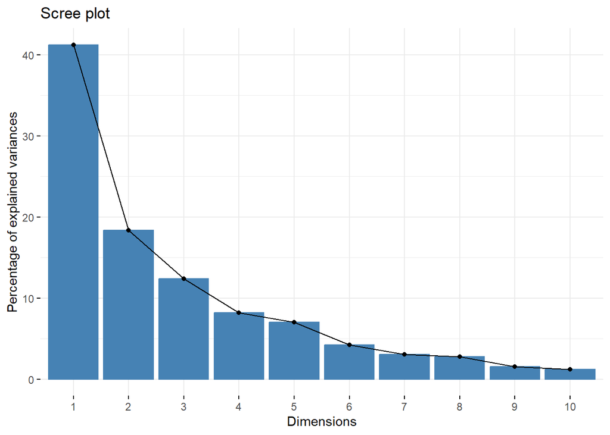

```r
library("factoextra")
data(decathlon2)
#On s'intéresse aux variables 1 à 10; les résultats aux épreuves
#On enlève les derniers individus, qui ne sont plus actifs
deca = decathlon2[1:23,1:10]
res.pca <- prcomp(deca, scale = TRUE)

#Regarder la variance expliquée
fviz_eig(res.pca)
```

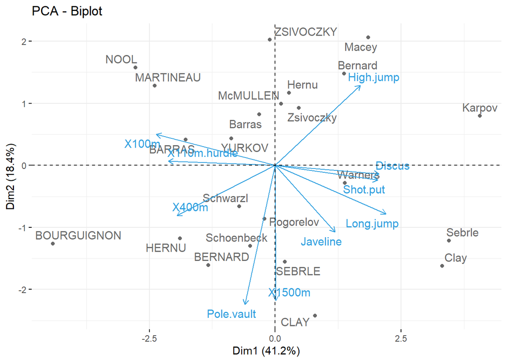

```r
#Bi-plot
fviz_pca_biplot(res.pca, repel = TRUE,
                col.var = "#2E9FDF", # Variables color
                col.ind = "#696969"  # Individuals color
                )
```

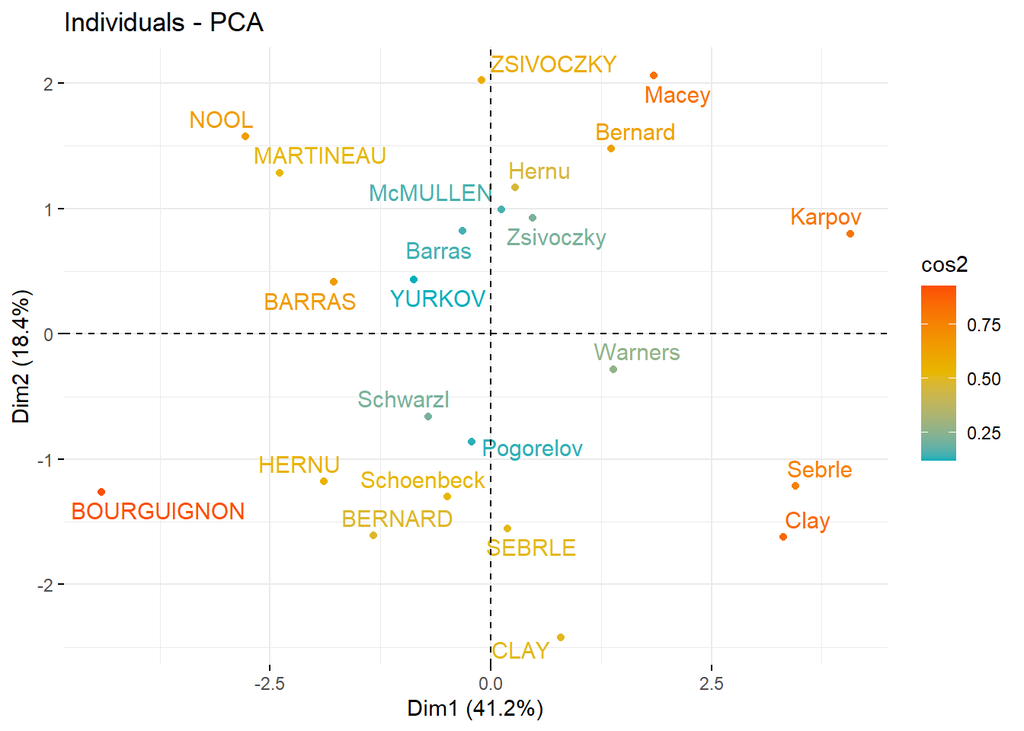

```r
#Graphique des individus
fviz_pca_ind(res.pca,
             col.ind = "cos2", # Color by the quality of representation
             gradient.cols = c("#00AFBB", "#E7B800", "#FC4E07"),
             repel = TRUE     # Avoid text overlapping
             )
```

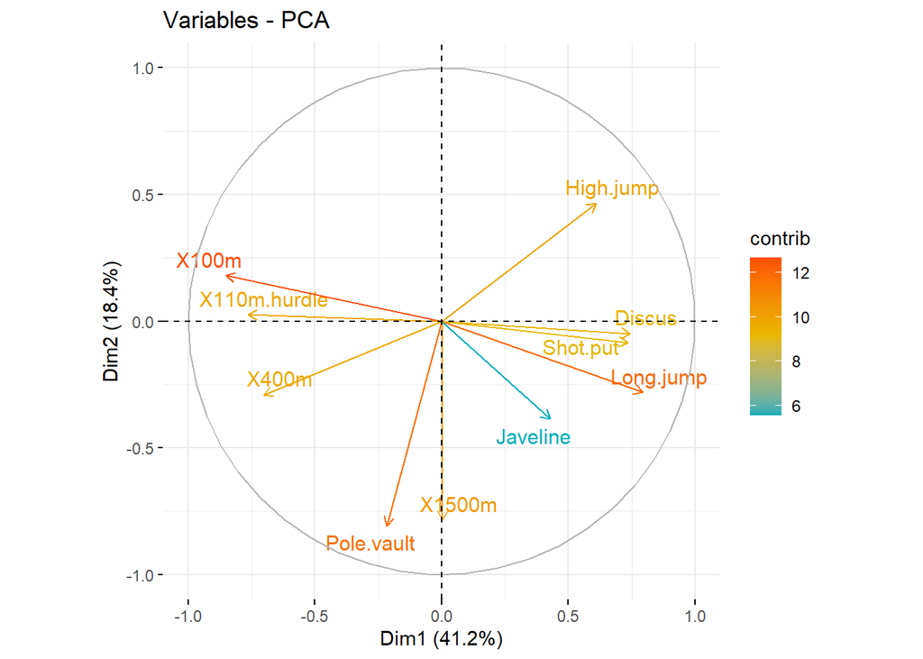

```r
#Graphique des variables
fviz_pca_var(res.pca,
             col.var = "contrib", # Color by contributions to the PC
             gradient.cols = c("#00AFBB", "#E7B800", "#FC4E07"),
             repel = TRUE     # Avoid text overlapping
             )
```

Vos notes ici :

Avez-vous remarqué cos2 dans le code ci-dessus? Ça va prendre un peu plus de mathématiques pour bien comprendre ce qui se passe. Vous pouvez regarder [ce document](https://personal.utdallas.edu/~herve/abdi-awPCA2010.pdf)

### Ajouter des individus / variables

On peut aussi positionner les individus omis de l’analyse sur les composantes principales qu’on vient de trouver.

```r
ind.sup <- decathlon2[24:27, 1:10]
#On peut simplement utiliser la fonction predict sur l'objet retourné par prcomp
ind.sup.coord <- predict(res.pca, newdata = ind.sup)
```

Qu’est-ce qu’elle fait exactement? On peut faire les calculs au long pour mieux comprendre.

```r
#On standardise d'abord les variables des nouvelles observations
ind.scaled <- scale(ind.sup,
                    center = res.pca$center,
                    scale = res.pca$scale)
# Petite fonction pour calculer les coordonnées des individus à partir de leurs variables et de la matrice des composantes principales
coord_func <- function(ind, loadings){
  r <- loadings*ind
  apply(r, 2, sum)
}

#On applique cette fonction à notre matrice de données
ind.sup.coord2 <- t(apply(ind.scaled, 1, coord_func, res.pca$rotation ))

#On peut vérifier que les deux méthodes donnent les mêmes résultats
max(ind.sup.coord2 - ind.sup.coord)
```

```
## [1] 4.440892e-16
```

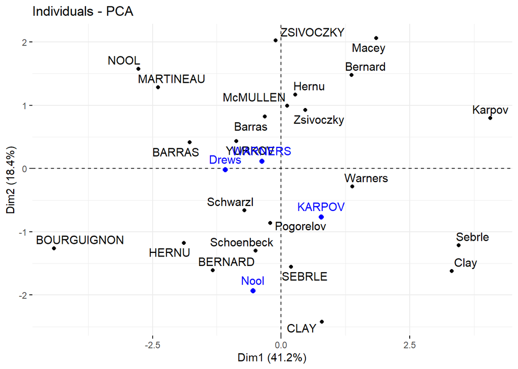

```r
#Et maintenant, on peut ajouter ces nouvelles observations à notre graphique
graph <- fviz_pca_ind(res.pca, repel = TRUE)
fviz_add(graph, ind.sup.coord, color ="blue")
```

Finalement, on peut aussi ajouter une autre variable à nos résultats, ici le type de compétiteur de décathlon.

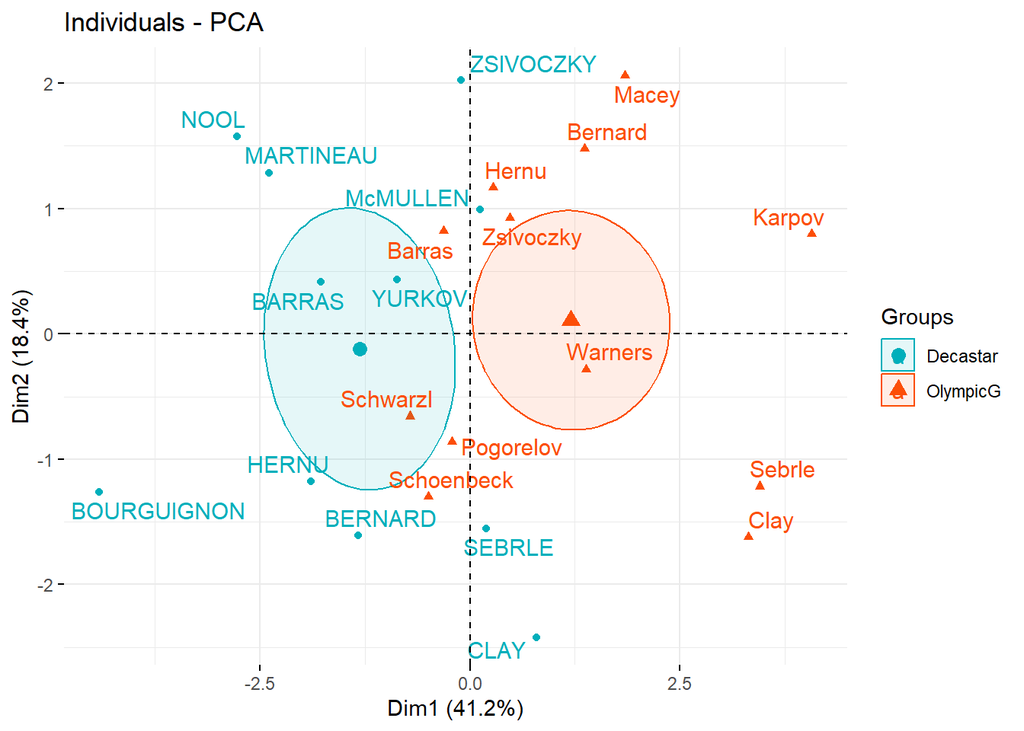

```r
groups <- as.factor(decathlon2$Competition[1:23])
fviz_pca_ind(res.pca,
             col.ind = groups, # color by groups
             palette = c("#00AFBB",  "#FC4E07"),
             addEllipses = TRUE, # Concentration ellipses
             ellipse.type = "confidence",
             legend.title = "Groups",
             repel = TRUE
             )
```